# EDA Salary Analysis

## Context

Information Technology in India is a vast industry that comprises information technology services, consulting, and outsourcing. The IT industry accounted for 8% of India's GDP in 2020. The IT and BPM industry's revenue is estimated at US Dollar 194 billion in FY 2021, an increase of 2.3 % YoY. The domestic revenue of the IT industry is estimated at US Dollar 45 billion and export revenue is estimated at US Dollar 150 billion in FY 2021.

The IT-BPM sector overall employs 4.5 million people as of March 2021. The Indian IT-BPM industry has the highest employee attrition rate. In recent years the industry has witnessed skyrocketing resignations cutting across the hierarchy. As a global outsourcing hub, the Indian IT industry is infamous for exploiting cheap labor. As the IT-BPM sector evolves, many are concerned that artificial intelligence (AI) will drive significant automation and destroy jobs in the coming years.

The software industry includes businesses for the development, maintenance, and publication of software that are using different business models, mainly either "license/maintenance based" (on-premises) or "Cloud-based" (such as SaaS, PaaS, IaaS, MBaaS, MSaaS, DCaaS, etc.). The industry also includes software services, such as training, documentation, consulting, and data recovery.

## CONTENT

This Dataset contains information of 22700+ Software Professionals with different features like their Salaries (₹), Name of the Company, Company Rating, Number of times Salaries Reported, and Location of the Company.

Structure of the Dataset Software Professional Salaries - 2022 ├── Rating

├── Company Name

├── Job Title

├── Salary (Indian Rupee - ₹) ├── Salaries Reported

├── Location

├── Employment Status

└── Job Roles

## Installing Required Packages

```python
pip install pandas
```

## Importing Packages

```python
import pandas as pd
import numpy as np
import matplotlib.pyplot as plt
import seaborn as sns
import plotly.express as px


plt.style.use("fivethirtyeight")


print("All Modules & Settings Initialized 🚀")
```

```
All Modules & Settings Initialized 🚀
```

## Importing Data

```python
salary_data = pd.read_csv('Salary_Dataset_with_Extra_Features.csv')

print("Data Imported Successfully 🚀")
```

```
Data Imported Successfully 🚀
```

## Cleaning, Exploring, Visualizing & Playing with the Data

```python
#First Five Rows of Data
salary_data.head(5)
```

|  | Rating | Company Name | Job Title | Salary | Salaries Reported | Location | Employment Status | Job Roles |
| --- | --- | --- | --- | --- | --- | --- | --- | --- |
| 0 | 3.8 | Sasken | Android Developer | 400000 | 3 | Bangalore | Full Time | Android |
| 1 | 4.5 | Advanced Millennium Technologies | Android Developer | 400000 | 3 | Bangalore | Full Time | Android |
| 2 | 4.0 | Unacademy | Android Developer | 1000000 | 3 | Bangalore | Full Time | Android |
| 3 | 3.8 | SnapBizz Cloudtech | Android Developer | 300000 | 3 | Bangalore | Full Time | Android |
| 4 | 4.4 | Appoids Tech Solutions | Android Developer | 600000 | 3 | Bangalore | Full Time | Android |

```python
salary_data.tail(5)
```

|  | Rating | Company Name | Job Title | Salary | Salaries Reported | Location | Employment Status | Job Roles |
| --- | --- | --- | --- | --- | --- | --- | --- | --- |
| 22765 | 4.7 | Expert Solutions | Web Developer | 200000 | 1 | Bangalore | Full Time | Web |
| 22766 | 4.0 | Nextgen Innovation Labs | Web Developer | 300000 | 1 | Bangalore | Full Time | Web |
| 22767 | 4.1 | Fresher | Full Stack Web Developer | 192000 | 13 | Bangalore | Full Time | Web |
| 22768 | 4.1 | Accenture | Full Stack Web Developer | 300000 | 7 | Bangalore | Full Time | Web |
| 22769 | 3.8 | Thomson Reuters | Associate Web Developer | 300000 | 7 | Bangalore | Full Time | Web |

```python
salary_data.columns
```

```
Index(['Rating', 'Company Name', 'Job Title', 'Salary', 'Salaries Reported',
       'Location', 'Employment Status', 'Job Roles'],
      dtype='object')
```

```python
salary_data.describe()
```

|  | Rating | Salary | Salaries Reported |
| --- | --- | --- | --- |
| count | 22770.000000 | 2.277000e+04 | 22770.000000 |
| mean | 3.918213 | 6.953872e+05 | 1.855775 |
| std | 0.519675 | 8.843990e+05 | 6.823668 |
| min | 1.000000 | 2.112000e+03 | 1.000000 |
| 25% | 3.700000 | 3.000000e+05 | 1.000000 |
| 50% | 3.900000 | 5.000000e+05 | 1.000000 |
| 75% | 4.200000 | 9.000000e+05 | 1.000000 |
| max | 5.000000 | 9.000000e+07 | 361.000000 |

```python
salary_data.shape
```

```
(22770, 8)
```

```python
salary_data.isna().sum()
```

```
Rating               0
Company Name         0
Job Title            0
Salary               0
Salaries Reported    0
Location             0
Employment Status    0
Job Roles            0
dtype: int64
```

```python
# using groupby function with aggregation
# to get mean, min and max values
result = salary_data.groupby('Location').agg({'Salary': ['mean', 'min', 'max']})

print("Mean, min, and max values of Salary")
print(result)
```

```
Mean, min, and max values of Salary
                       Salary
                         mean    min       max
Location
Bangalore       735344.739593   2112  10000000
Chennai         584559.661513  12000  10000000
Hyderabad       679099.157376   8448   9700000
Jaipur          629135.802469  36000   2500000
Kerala          553577.481481  72000   2900000
Kolkata         710925.573034  60000   9850000
Madhya Pradesh  677641.909677  96000   7800000
Mumbai          961180.368491  12000   9800000
New Delhi       658756.735632  12000  90000000
Pune            690476.311153  23232  10000000
```

## Maximum Salary Paid

```python
maximum_salary=salary_data.max()
print("Highest Paid Salary")
print(maximum_salary)
```

```
Highest Paid Salary
Rating                                5.0
Company Name         eNotice Ninja Pluss
Job Title                      oracle dba
Salary                           90000000
Salaries Reported                     361
Location                             Pune
Employment Status                 Trainee
Job Roles                             Web
dtype: object
```

## Minimum Salary Paid

```python
minimum_salary=salary_data.min()
print("Lowest Paid Salary")
print(minimum_salary)
```

```
Lowest Paid Salary
Rating                                         1.0
Company Name         (X,Y,Z) Architecture & Design
Job Title                             "ORACLE DBA"
Salary                                        2112
Salaries Reported                                1
Location                                 Bangalore
Employment Status                       Contractor
Job Roles                                  Android
dtype: object
```

## What is the change of salary in different locations?

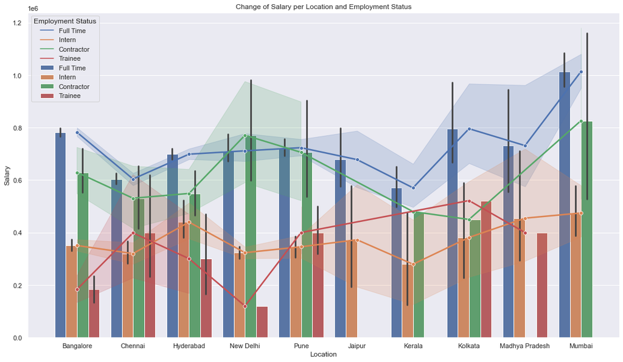

```python
# What is the change of salary in different locations?
sns.set(rc={'figure.figsize':(15.7,9.27)})
sns.barplot(data=salary_data, x="Location", y="Salary", hue="Employment Status")
sns.lineplot(data=salary_data, x="Location", y="Salary", hue="Employment Status", linewidth=2.5, marker='o')

# Descriptions
plt.title("Change of Salary per Location and Employment Status")
plt.show()
```

## How does Salary change with rating and employment status?

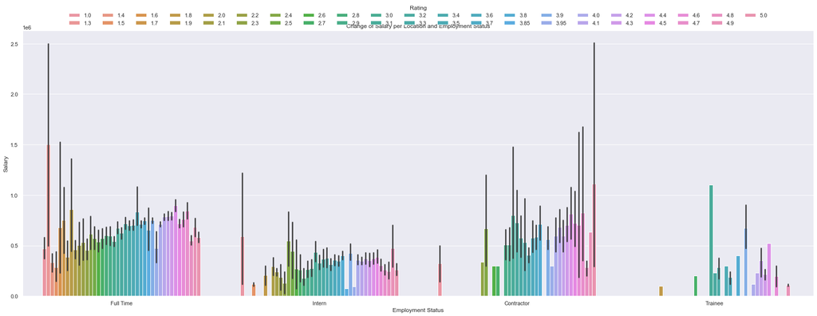

```python
# How does Salary change with rating and employment status?
sns.set(rc={'figure.figsize':(25.7,9.27)})

# figure_1 = sns.lineplot(data=salary_data, x="Employment Status", y="Salary", hue="Rating")
figure_1 = sns.barplot(data=salary_data, x="Employment Status", y="Salary", hue="Rating")
sns.move_legend(figure_1, "lower center", bbox_to_anchor=(.5, 1), ncol=21, title="Rating", frameon=False)

# Descriptions
plt.title("Change of Salary per Location and Employment Status")
plt.show()
```

## Change of Salary per Job Role and Employment Status

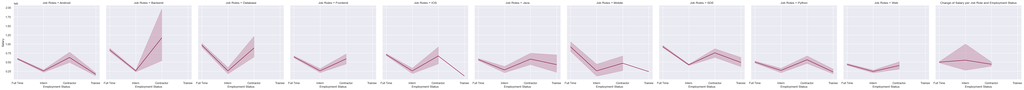

```python
# Change of Salary per Job Role and Employment Status
sns.relplot(col="Job Roles", y="Salary", kind="line",x='Employment Status', data=salary_data, color="#840032")

# Descriptions
plt.title("Change of Salary per Job Role and Employment Status")
plt.show()
```

## Frequency of Employment Status

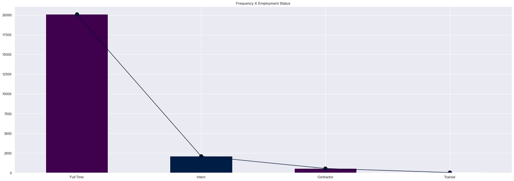

```python
# Frequency of Employment Status
salary_data["Employment Status"].value_counts().plot.line(color=["#00132d"], marker="o", markersize=12)
salary_data["Employment Status"].value_counts().plot.bar(color=["#3f004d", "#001e45"])

# Descriptions
plt.title("Frequency X Employment Status")
plt.xticks(rotation = 360)
plt.show()
```

## Frequency of Location

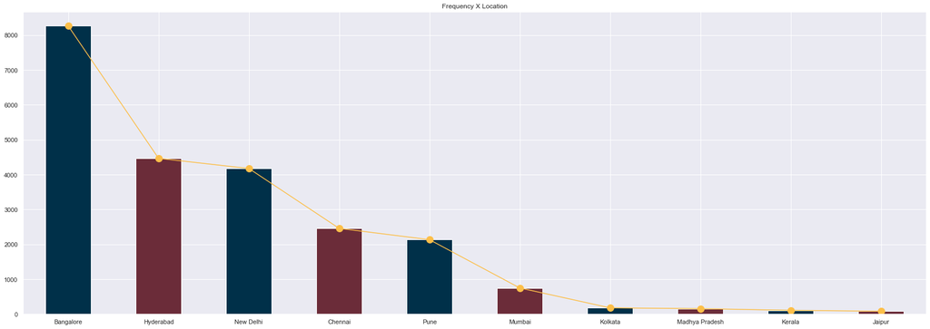

```python
# Frequency of Location
salary_data["Location"].value_counts().plot.bar(color=["#003049", "#6B2C39"])

salary_data["Location"].value_counts().plot.line(color=["#FCBF49"], marker="o", markersize=12)

# Descriptions
plt.title("Frequency X Location")
plt.show()
```

## Frequency of Job Roles

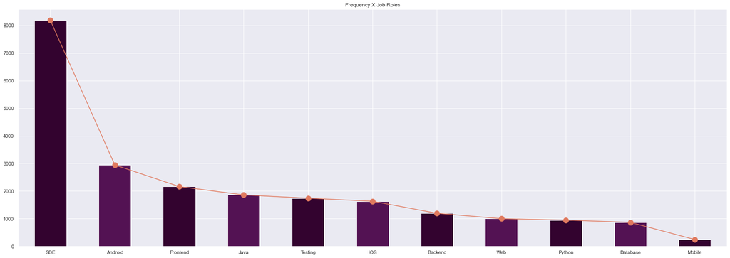

```python
# Frequency of Job Roles
salary_data["Job Roles"].value_counts().plot.line(color=["#e07a5f"], marker="o", markersize=12)
salary_data["Job Roles"].value_counts().plot.bar(color=["#33032f", "#531253"])

# Descriptions
plt.title("Frequency X Job Roles")
plt.xticks(rotation = 360)
plt.show()
```

## How does Salary change with Employment status?

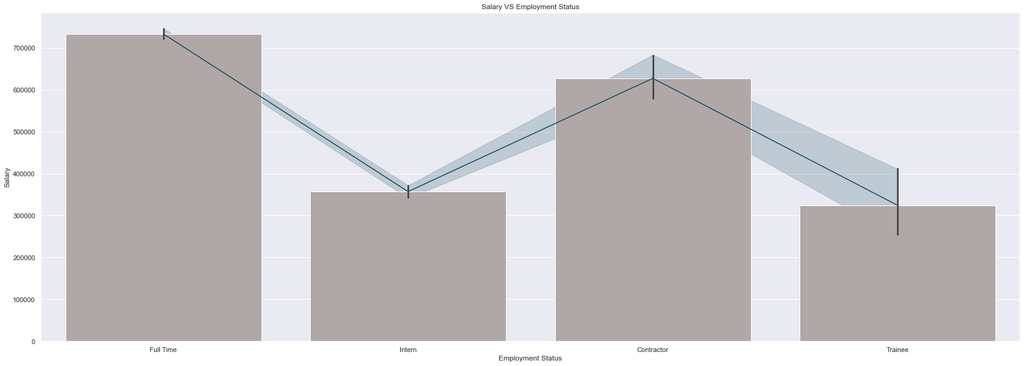

```python
# How does Salary change with Employment status?
sns.set(rc={'figure.figsize':(25.7,9.27)})
figure_1 = sns.lineplot(data=salary_data, x="Employment Status", y="Salary", color="#0f4c5c")
figure_1 = sns.barplot(data=salary_data, x="Employment Status", y="Salary", color="#b1a7a6")

# Descriptions
plt.title("Salary VS Employment Status")
plt.show()
```